# Assignment 2 - The tidyverse

Hyebin-Hong

October 06, 2021 | 23:11:08 | CEST

```r
library(devtools)
library(tidyverse)
library(dplyr)
library(tibble)
library(legislatoR)
```

### Getting started with the Comparative Legislators Database

The Comparative Legislators Database (CLD) includes political, sociodemographic, career, online presence, public attention, and visual information for over 45,000 contemporary and historical politicians from ten countries (see the [corresponding article](https://www.cambridge.org/core/journals/british-journal-of-political-science/article/comparative-legislators-database/D28BB58A8B2C08C8593DB741F42C18B2) for more information). It can be accessed via `legislatoR` - an R package that is available on both [CRAN](https://cran.r-project.org/web/packages/legislatoR/index.html) and [GitHub](https://github.com/saschagobel/legislatoR).

Before you start with the following tasks, skim the tutorial to make yourself familiar with the database. You find it [here](https://cran.r-project.org/web/packages/legislatoR/vignettes/legislatoR.html).

For the following tasks, you will work with ONE of the legislatures. The legislature you’ll work with depends on your prename:

| Your prename starts with… | Legislature | Code |
| --- | --- | --- |
| A-C | Austrian Nationalrat | `aut` |
| D-F | Canadian House of Commons | `can` |
| G-I | Czech Poslanecka Snemovna | `cze` |
| J-L | Spanish Congreso de los Diputados | `esp` |
| M-O | French Assemblée | `fra` |
| P-R | German Bundestag | `deu` |
| S-U | Irish Dail | `irl` |
| V-X | UK House of Commons | `gbr` |
| Y-Z | US House of Representatives | `usa_house` |

The following tasks will be based on data from the `core` and `political` tables of the database.

### Task 1 - Fun with descriptives [8 points in total]

1. What’s the overall share of female legislators in the entire dataset? [1 point]

```r
cze_whole <- get_core(legislature = "cze")

cze_female <- filter(get_core(legislature = "cze"), sex == "female")

nrow(cze_female)/nrow(cze_whole)
```

```
[1] 0.1843137
```

2. How many (both in absolute and relative terms) legislators died in the same place they were born in? [1 point]

```r
length(which(cze_whole$birthplace == cze_whole$deathplace))
```

```
[1] 6
```

3. Create a new variable `age_at_death` that reports the age at which legislators died. Then, plot the distribution of that variable for the entire dataset. [2 points]

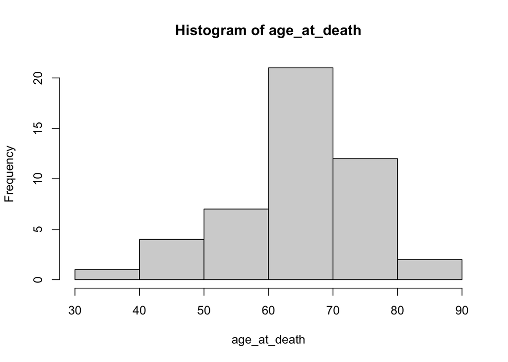

```r
age_at_death <- as.vector(na.omit(strtoi(substr(cze_whole$death,1,4)) - strtoi(substr(cze_whole$birth,1,4))))

hist(age_at_death)
```

4. Provide one single table that provides the 5 legislators with the highest and lowest age at death, ignoring ties. [2 points]

```r
legis <- as.vector(strtoi(substr(cze_whole$death,1,4)) - strtoi(substr(cze_whole$birth,1,4)))

mydata <- data.frame(legis, cze_whole$name)

high <- mydata %>%
  arrange(desc(legis)) %>%
  slice(1:5)

low <- mydata %>%
  arrange(legis) %>%
  slice(1:5)

table <- data.frame(high,low)
table
```

| legis | cze_whole.name | legis.1 | cze_whole.name.1 |
| --- | --- | --- | --- |
| 89 | Augustin Bubník | 39 | Petr Jalowiczor |
| 84 | Vítězslav Sochor | 43 | Josef Lux |
| 77 | Andrej Gjurič | 45 | Marie Noveská |
| 77 | Tomáš Ježek | 46 | Stanislav Gross |
| 77 | Miloš Skočovský | 48 | Vladimír Řezáč |

5. Find out who has got the longest name and who the shortest (both in terms of number of characters, ignoring whitespace)! [2 points]

```r
counting_name <-nchar(cze_whole$name)
name <- data.frame(cze_whole$name,counting_name)

name_sort <- arrange(name,desc(counting_name))

name_sort$cze_whole.name[1]
```

```
[1] "Zuzana Majerová Zahradníková"
```

```r
name_sort$cze_whole.name[nrow(name_sort)]
```

```
[1] "Dan Ťok"
```

longest name:Zuzana Majerová Zahradníková shortest name:Dan Ťok

### Task 2 - Exploring trends in the data [8 points in total]

1. Using data from all sessions, provide a plot that shows the share of female legislators by session! [3 points]

[figure not shown]

```r
leg = c("aut", "can", "cze", "fra", "deu","irl","sco","esp","gbr","usa_house/usa_senate")
ratio=list()
for (i in (1:9)) {
  cont = leg[i]
  whole <- get_core(legislature = cont)
  female <- filter(get_core(legislature = cont), sex == "female")
  ratio[length(ratio) +1]= nrow(female)/nrow(whole)
}

barplot(unlist(ratio), name.arg = c("aut", "can", "cze", "fra", "deu","irl","sco","esp","gbr","usa_house/usa_senate"), xlab = "by session", ylab = "share of female")
```

2. Explore another relation of variables in the dataset. Your analysis should (i) use data from both the `core` and the `political` table and (ii) feature data from several sessions. Also, offer a brief description and interpretation of your findings! [5 points]

```r
deu_subset <- inner_join(x = get_core(legislature = "deu"),
                         y = filter(get_political(legislature = "deu"),
                                    party %in% c("CDU", "CSU", "AfD")),
                         by = "pageid")
summary(deu_subset)
```

```
   country             pageid           wikidataid         wikititle
 Length:5212        Length:5212        Length:5212        Length:5212
 Class :character   Class :character   Class :character   Class :character
 Mode  :character   Mode  :character   Mode  :character   Mode  :character




     name               sex             ethnicity           religion
 Length:5212        Length:5212        Length:5212        Length:5212
 Class :character   Class :character   Class :character   Class :character
 Mode  :character   Mode  :character   Mode  :character   Mode  :character




     birth                         death                      birthplace
 Min.   :1876-01-05 00:00:00   Min.   :1949-11-25 00:00:00   Length:5212
 1st Qu.:1917-12-19 00:00:00   1st Qu.:1981-09-25 00:00:00   Class :character
 Median :1936-09-25 00:00:00   Median :1994-10-02 00:00:00   Mode  :character
 Mean   :1934-11-15 18:33:23   Mean   :1993-09-28 06:56:50
 3rd Qu.:1951-02-05 00:00:00   3rd Qu.:2008-01-24 00:00:00
 Max.   :1992-11-10 00:00:00   Max.   :2018-12-10 00:00:00
 NA's   :1                     NA's   :2742
  deathplace           session         party           constituency
 Length:5212        Min.   : 1.00   Length:5212        Length:5212
 Class :character   1st Qu.: 6.00   Class :character   Class :character
 Mode  :character   Median :11.00   Mode  :character   Mode  :character
                    Mean   :10.33
                    3rd Qu.:15.00
                    Max.   :19.00

 constituency2      session_start         session_end            service
 Length:5212        Min.   :1949-09-07   Min.   :1953-10-06   Min.   :   9
 Class :character   1st Qu.:1969-10-20   1st Qu.:1972-12-13   1st Qu.:1390
 Mode  :character   Median :1987-02-18   Median :1990-12-20   Median :1452
                    Mean   :1985-02-22   Mean   :1988-12-11   Mean   :1304
                    3rd Qu.:2002-10-17   3rd Qu.:2005-10-18   3rd Qu.:1463
                    Max.   :2017-10-24   Max.   :2021-10-24   Max.   :1490
```

I have made a summary table for German legislatures from CDU, CSU and AFD.

### Task 3 - Fun with functions [3 points in total]

1. Program a function `ultimate_answer()` that always returns the number 42, and prove that it works! [1 point]

```r
ultimate_answer <- function(...) 42L
ultimate_answer(10, c = 56,30)
```

```
[1] 42
```

2. Program a robust function `normalize()` that normalizes a numeric vector x to mean(x) = 0 and sd(x) = 1! Then, apply it to all numeric variables in the mtcars dataset! [2 points]

```r
normalize <- function(x) {
  (x*min(x)) = 0 &
  sd(x) = 1
}
```